# Analyse test-retest data

Load in the relevant libraries

```r
library('faux') #for sample size sim at end
```

Load data

```r
data<-read_csv(paste0(workingdir,'dataset.csv'))
```

Characterise participants

```r
data%>%
  select(age,prolific_score,phq8_score,gad7_score,gap)%>%
  summarise(across(everything(),list(mean=mean,sd=sd)))
```

| age_mean | age_sd | prolific_score_mean | prolific_score_sd | phq8_score_mean | phq8_score_sd | gad7_score_mean | gad7_score_sd | gap_mean | gap_sd |
| --- | --- | --- | --- | --- | --- | --- | --- | --- | --- |
| 27.96552 | 8.429201 | 99.43103 | 1.666092 | 7.862069 | 5.289673 | 6.603448 | 4.877228 | 15.67241 | 3.600136 |

```r
sum(data$Sex=='Female')
```

```
[1] 35
```

Mark bad participants

```r
data<-data%>%
  mutate(bad_participants=case_when(
    p_big_big_1 < 0.5 ~ 1,
    p_big_big_2 < 0.5 ~ 1,
    p_big_small_1 > 0.5 ~ 1,
    p_big_small_2 > 0.5 ~ 1,
    TRUE ~ 0))
```

Plot data

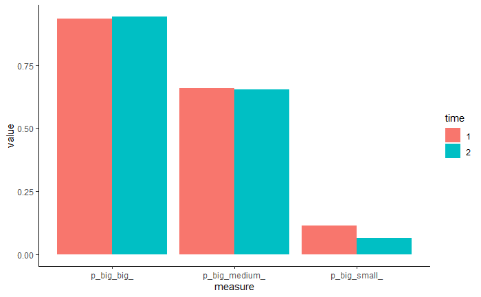

```r
data%>%
  select(id,contains('p_big_'),-c('p_big_1','p_big_2'))%>%
  pivot_longer(cols=-c('id'))%>%
  separate(name,into=c('measure','time'),sep=-1)%>%
  ggplot(aes(x=measure,y=value,fill=time))+
  geom_bar(position='dodge',stat='summary',fun='mean')+
  theme_classic()
```

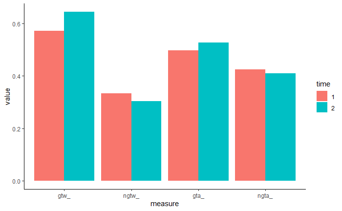

```r
data%>%
  select(id,contains(c('gtw','gta','ngtw','ngta')))%>%
  pivot_longer(cols=-c('id'))%>%
  separate(name,into=c('measure','time'),sep=-1)%>%
  mutate(measure=factor(measure,levels=c('gtw_','ngtw_','gta_','ngta_')))%>%
  ggplot(aes(x=measure,y=value,fill=time))+
  geom_bar(position='dodge',stat='summary',fun='mean')+
  theme_classic()
```

```r
NA
NA
```

Get ICCs for go/nogo

```r
#go to win
cor_gtw<-cor.test(data$gtw_1,data$gtw_2)
cor_gtw
```

```
    Pearson's product-moment correlation

data:  data$gtw_1 and data$gtw_2
t = 3.6639, df = 56, p-value = 0.0005529
alternative hypothesis: true correlation is not equal to 0
95 percent confidence interval:
 0.2046805 0.6268292
sample estimates:
      cor
0.4397287
```

```r
icc_a1_gtw<-icc(cbind(data$gtw_1,data$gtw_2),model = "twoway",
    type = "agreement",
    unit = "single",
    r0 = 0,
    conf.level = 0.95)
print(icc_a1_gtw)
```

```
 Single Score Intraclass Correlation

   Model: twoway
   Type : agreement

   Subjects = 58
     Raters = 2
   ICC(A,1) = 0.43

 F-Test, H0: r0 = 0 ; H1: r0 > 0
   F(57,57) = 2.57 , p = 0.000248

 95%-Confidence Interval for ICC Population Values:
  0.2 < ICC < 0.616
```

```r
icc_c1_gtw<-icc(cbind(data$gtw_1,data$gtw_2),model = "twoway",
    type = "consistency",
    unit = "single",
    r0 = 0,
    conf.level = 0.95)
print(icc_c1_gtw)
```

```
 Single Score Intraclass Correlation

   Model: twoway
   Type : consistency

   Subjects = 58
     Raters = 2
   ICC(C,1) = 0.44

 F-Test, H0: r0 = 0 ; H1: r0 > 0
   F(57,57) = 2.57 , p = 0.000247

 95%-Confidence Interval for ICC Population Values:
  0.207 < ICC < 0.625
```

```r
#nogo to win
cor_ngtw<-cor.test(data$ngtw_1,data$ngtw_2)
cor_ngtw
```

```
    Pearson's product-moment correlation

data:  data$ngtw_1 and data$ngtw_2
t = 1.3622, df = 56, p-value = 0.1786
alternative hypothesis: true correlation is not equal to 0
95 percent confidence interval:
 -0.08305491  0.41804141
sample estimates:
      cor
0.1790827
```

```r
icc_a1_ngtw<-icc(cbind(data$ngtw_1,data$ngtw_2),model = "twoway",
    type = "agreement",
    unit = "single",
    r0 = 0,
    conf.level = 0.95)
print(icc_a1_ngtw)
```

```
 Single Score Intraclass Correlation

   Model: twoway
   Type : agreement

   Subjects = 58
     Raters = 2
   ICC(A,1) = 0.18

 F-Test, H0: r0 = 0 ; H1: r0 > 0
 F(57,57.2) = 1.43 , p = 0.0886

 95%-Confidence Interval for ICC Population Values:
  -0.083 < ICC < 0.418
```

```r
icc_c1_ngtw<-icc(cbind(data$ngtw_1,data$ngtw_2),model = "twoway",
    type = "consistency",
    unit = "single",
    r0 = 0,
    conf.level = 0.95)
print(icc_c1_ngtw)
```

```
 Single Score Intraclass Correlation

   Model: twoway
   Type : consistency

   Subjects = 58
     Raters = 2
   ICC(C,1) = 0.178

 F-Test, H0: r0 = 0 ; H1: r0 > 0
   F(57,57) = 1.43 , p = 0.0888

 95%-Confidence Interval for ICC Population Values:
  -0.082 < ICC < 0.415
```

```r
#go to avoid
cor_gta<-cor.test(data$gta_1,data$gta_2)
cor_gta
```

```
    Pearson's product-moment correlation

data:  data$gta_1 and data$gta_2
t = 4.2665, df = 56, p-value = 7.723e-05
alternative hypothesis: true correlation is not equal to 0
95 percent confidence interval:
 0.2717679 0.6681173
sample estimates:
      cor
0.4952957
```

```r
icc_a1_gta<-icc(cbind(data$gta_1,data$gta_2),model = "twoway",
    type = "agreement",
    unit = "single",
    r0 = 0,
    conf.level = 0.95)
print(icc_a1_gta)
```

```
 Single Score Intraclass Correlation

   Model: twoway
   Type : agreement

   Subjects = 58
     Raters = 2
   ICC(A,1) = 0.496

 F-Test, H0: r0 = 0 ; H1: r0 > 0
 F(57,57.7) = 2.96 , p = 3.09e-05

 95%-Confidence Interval for ICC Population Values:
  0.276 < ICC < 0.668
```

```r
icc_c1_gta<-icc(cbind(data$gta_1,data$gta_2),model = "twoway",
    type = "consistency",
    unit = "single",
    r0 = 0,
    conf.level = 0.95)
print(icc_c1_gta)
```

```
 Single Score Intraclass Correlation

   Model: twoway
   Type : consistency

   Subjects = 58
     Raters = 2
   ICC(C,1) = 0.495

 F-Test, H0: r0 = 0 ; H1: r0 > 0
   F(57,57) = 2.96 , p = 3.33e-05

 95%-Confidence Interval for ICC Population Values:
  0.274 < ICC < 0.667
```

```r
#nogo to avoid
cor_ngta<-cor.test(data$ngta_1,data$ngta_2)
cor_ngta
```

```
    Pearson's product-moment correlation

data:  data$ngta_1 and data$ngta_2
t = 3.8997, df = 56, p-value = 0.0002603
alternative hypothesis: true correlation is not equal to 0
95 percent confidence interval:
 0.2314633 0.6436016
sample estimates:
      cor
0.4621302
```

```r
icc_a1_ngta<-icc(cbind(data$ngta_1,data$ngta_2),model = "twoway",
    type = "agreement",
    unit = "single",
    r0 = 0,
    conf.level = 0.95)
print(icc_a1_ngta)
```

```
 Single Score Intraclass Correlation

   Model: twoway
   Type : agreement

   Subjects = 58
     Raters = 2
   ICC(A,1) = 0.461

 F-Test, H0: r0 = 0 ; H1: r0 > 0
 F(57,57.2) = 2.69 , p = 0.000134

 95%-Confidence Interval for ICC Population Values:
  0.23 < ICC < 0.642
```

```r
icc_c1_ngta<-icc(cbind(data$ngta_1,data$ngta_2),model = "twoway",
    type = "consistency",
    unit = "single",
    r0 = 0,
    conf.level = 0.95)
print(icc_c1_ngta)
```

```
 Single Score Intraclass Correlation

   Model: twoway
   Type : consistency

   Subjects = 58
     Raters = 2
   ICC(C,1) = 0.457

 F-Test, H0: r0 = 0 ; H1: r0 > 0
   F(57,57) = 2.69 , p = 0.000136

 95%-Confidence Interval for ICC Population Values:
  0.228 < ICC < 0.639
```

Get ICCs for circles

```r
#go to win
cor_pmidhigh<-cor.test(data$p_big_medium_1,data$p_big_medium_2)
cor_pmidhigh
```

```
    Pearson's product-moment correlation

data:  data$p_big_medium_1 and data$p_big_medium_2
t = 4.1375, df = 56, p-value = 0.0001191
alternative hypothesis: true correlation is not equal to 0
95 percent confidence interval:
 0.2577821 0.6597067
sample estimates:
      cor
0.4838605
```

```r
icc_a1_pmidhigh<-icc(cbind(data$p_big_medium_1,data$p_big_medium_2),model = "twoway",
    type = "agreement",
    unit = "single",
    r0 = 0,
    conf.level = 0.95)
print(icc_a1_pmidhigh)
```

```
 Single Score Intraclass Correlation

   Model: twoway
   Type : agreement

   Subjects = 58
     Raters = 2
   ICC(A,1) = 0.488

 F-Test, H0: r0 = 0 ; H1: r0 > 0
 F(57,57.1) = 2.87 , p = 5.16e-05

 95%-Confidence Interval for ICC Population Values:
  0.263 < ICC < 0.662
```

```r
icc_c1_pmidhigh<-icc(cbind(data$p_big_medium_1,data$p_big_medium_2),model = "twoway",
    type = "consistency",
    unit = "single",
    r0 = 0,
    conf.level = 0.95)
print(icc_c1_pmidhigh)
```

```
 Single Score Intraclass Correlation

   Model: twoway
   Type : consistency

   Subjects = 58
     Raters = 2
   ICC(C,1) = 0.484

 F-Test, H0: r0 = 0 ; H1: r0 > 0
   F(57,57) = 2.87 , p = 5.19e-05

 95%-Confidence Interval for ICC Population Values:
  0.26 < ICC < 0.658
```

Create plot

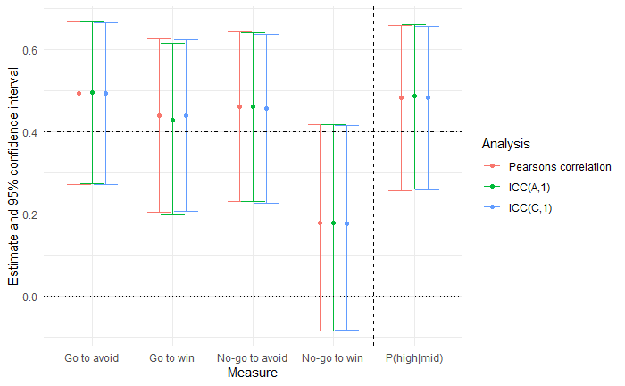

```r
summary_coefs<-data.frame(
  task=c('gng','gng','gng','gng','ambiguous'),
  measure=c('gtw','ngtw','gta','ngta','pmidhigh'),
  corr_coef=c(cor_gtw$estimate,cor_ngtw$estimate,cor_gta$estimate,cor_ngta$estimate,cor_pmidhigh$estimate),
  corr_p=c(cor_gtw$p.value,cor_ngtw$p.value,cor_gta$p.value,cor_ngta$p.value,cor_pmidhigh$p.value),
  corr_lb=c(cor_gtw$conf.int[1],cor_ngtw$conf.int[1],cor_gta$conf.int[1],cor_ngta$conf.int[1],cor_pmidhigh$conf.int[1]),
  corr_ub=c(cor_gtw$conf.int[2],cor_ngtw$conf.int[2],cor_gta$conf.int[2],cor_ngta$conf.int[2],cor_pmidhigh$conf.int[2]),
  icc.a1_coef=c(icc_a1_gtw$value,icc_a1_ngtw$value,icc_a1_gta$value,icc_a1_ngta$value,icc_a1_pmidhigh$value),
  icc.a1_p=c(icc_a1_gtw$p.value,icc_a1_ngtw$p.value,icc_a1_gta$p.value,icc_a1_ngta$p.value,icc_a1_pmidhigh$p.value),
  icc.a1_lb=c(icc_a1_gtw$lbound,icc_a1_ngtw$lbound,icc_a1_gta$lbound,icc_a1_ngta$lbound,icc_a1_pmidhigh$lbound),
  icc.a1_ub=c(icc_a1_gtw$ubound,icc_a1_ngtw$ubound,icc_a1_gta$ubound,icc_a1_ngta$ubound,icc_a1_pmidhigh$ubound),
  icc.c1_coef=c(icc_c1_gtw$value,icc_c1_ngtw$value,icc_c1_gta$value,icc_c1_ngta$value,icc_c1_pmidhigh$value),
  icc.c1_p=c(icc_c1_gtw$p.value,icc_c1_ngtw$p.value,icc_c1_gta$p.value,icc_c1_ngta$p.value,icc_c1_pmidhigh$p.value),
  icc.c1_lb=c(icc_c1_gtw$lbound,icc_c1_ngtw$lbound,icc_c1_gta$lbound,icc_c1_ngta$lbound,icc_c1_pmidhigh$lbound),
  icc.c1_ub=c(icc_c1_gtw$ubound,icc_c1_ngtw$ubound,icc_c1_gta$ubound,icc_c1_ngta$ubound,icc_c1_pmidhigh$ubound)
)

summary_coefs<-summary_coefs%>%
  pivot_longer(cols = -c(task,measure))%>%
  separate(col = name, into=c('analysis','number'), sep = '_')%>%
  pivot_wider(names_from=number,values_from=value)

ggplot(summary_coefs,aes(x=measure,y=coef,colour=analysis,group=analysis))+
  geom_errorbar(aes(ymin=lb,ymax=ub),position=position_dodge(0.5))+
  geom_point(position=position_dodge(0.5))+
  theme_minimal()+
  labs(x='Measure',y='Estimate and 95% confidence interval',colour='Analysis')+
  scale_x_discrete(labels=c('Go to avoid','Go to win','No-go to avoid', 'No-go to win','P(high|mid)'))+
  scale_colour_discrete(labels=c('Pearsons correlation','ICC(A,1)','ICC(C,1)'))+
  geom_vline(aes(xintercept=4.5),linetype='dashed')+
  geom_hline(yintercept=0,linetype='dotted')+
  geom_hline(yintercept=0.4,linetype='dotdash')


ggsave(filename=paste0(workingdir,'figures/summary_stats.png'),width=10,height=6,scale=0.8)
```

GNG model comparison

```r
source(paste0(workingdir,'model_selection.R'))

model_list<-read.csv('model_details.csv')
model_list<-model_list

times<-c(1:2)

ibics<-list()
bics<-list()
looic<-list()


for (time in times){
  temp_list<-paste0('gng_',times[time],'_',substr(model_list$Model_name,6,7),'.RData')
  temp<-mapply(model_selection, temp_list, ntrials=160, nparam=model_list$Parameters,llname='log_lik',workingdir=workingdir)
  ibics[[time]]<-temp[1,]
  bics[[time]]<-temp[2,]
  looic[[time]]<-temp[3,]
}
```

[output not shown]

[output not shown]

[output not shown]

[output not shown]

[output not shown]

[output not shown]

[output not shown]

[output not shown]

[output not shown]

[output not shown]

[output not shown]

[output not shown]

[output not shown]

[output not shown]

```r
ibics_df<-data.frame(do.call(rbind,ibics))%>%
  setNames(model_list$Model_name)%>%
  mutate(time=times)%>%
  pivot_longer(cols=contains('_'),names_to='model',values_to='ibic')

looic_df<-data.frame(do.call(rbind,looic))%>%
  setNames(model_list$Model_name)%>%
  mutate(time=times)%>%
  pivot_longer(cols=contains('_'),names_to='model',values_to='looic')


bics_df<-data.frame(do.call(rbind,bics))%>%
  setNames(model_list$Model_name)%>%
  mutate(time=times)%>%
  pivot_longer(cols=contains('_'),names_to='model',values_to='bic')
```

Get best model for time 1

```r
bics_df$bic<-as.numeric(bics_df$bic)

bics_t1<-bics_df%>%
  filter(time==1)%>%
  group_by(model)%>%
  summarize(total=sum(bic))%>%
  mutate(model=factor(model,ordered=TRUE,levels=c(model_list$Model_name)))

bics_t1%>%
  arrange(total)%>%
  mutate(bayesfactor = exp((total - lag(total, default = total[1]))/2))
```

| model | total | bayesfactor |
| --- | --- | --- |
| gng_m5 | 141.2901 | 1.000000e+00 |
| gng_m6 | 146.7796 | 1.556094e+01 |
| gng_m4 | 149.2045 | 3.361796e+00 |
| gng_m3 | 150.5839 | 1.993118e+00 |
| gng_m7 | 153.7896 | 4.967015e+00 |
| gng_m2 | 159.9622 | 2.189615e+01 |
| gng_m1 | 216.7047 | 2.096429e+12 |

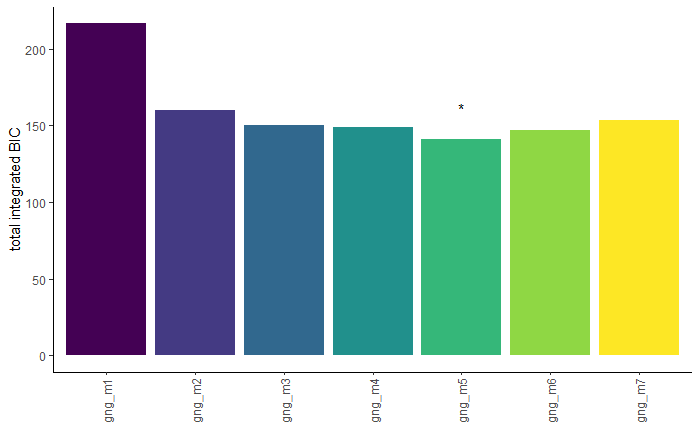

```r
bic_t1_plot<-ggplot(bics_t1,aes(x=model,y=total,fill=model))+
  stat_summary(geom='bar',fun='sum')+
  theme_classic()+
  theme(axis.text.x = element_text(angle = 90, vjust = 0.5, hjust=1),legend.position = 'none', axis.title.x=element_blank())+
  geom_text(data = bics_t1[which.min(bics_t1$total),], label = "*", nudge_y=20)+
  labs(y='total integrated BIC')
bic_t1_plot

ggsave(filename=paste0(workingdir,'/figures/bics_t1.png'),bic_t1_plot,width=10,height=8,scale=0.7)
```

And the best model for time 2

```r
bics_df$bic<-as.numeric(bics_df$bic)

bics_t2<-bics_df%>%
  filter(time==2)%>%
  group_by(model)%>%
  summarize(total=sum(bic))%>%
  mutate(model=factor(model,ordered=TRUE,levels=c(model_list$Model_name)))

bics_t2%>%
  arrange(total)%>%
  mutate(bayesfactor = exp((total - lag(total, default = total[1]))/2))
```

| model | total | bayesfactor |
| --- | --- | --- |
| gng_m5 | 122.3431 | 1.000000e+00 |
| gng_m4 | 125.9386 | 6.036049e+00 |
| gng_m3 | 126.9919 | 1.693201e+00 |
| gng_m6 | 127.4325 | 1.246458e+00 |
| gng_m7 | 130.5869 | 4.841389e+00 |
| gng_m2 | 137.0243 | 2.499568e+01 |
| gng_m1 | 205.4605 | 7.256456e+14 |

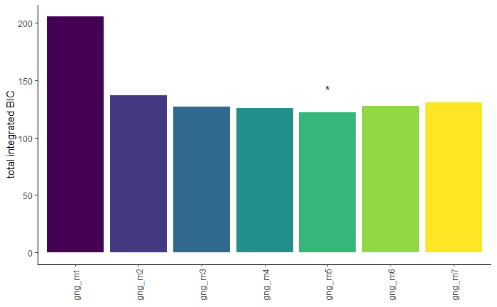

```r
bic_t2_plot<-ggplot(bics_t2,aes(x=model,y=total,fill=model))+
  stat_summary(geom='bar',fun='sum')+
  theme_classic()+
  theme(axis.text.x = element_text(angle = 90, vjust = 0.5, hjust=1),legend.position = 'none', axis.title.x=element_blank())+
  geom_text(data = bics_t2[which.min(bics_t2$total),], label = "*", nudge_y=20)+
  labs(y='total integrated BIC')
bic_t2_plot

ggsave(filename=paste0(workingdir,'/figures/bics_t2.png'),bic_t2_plot,width=10,height=8,scale=0.7)
```

Combine

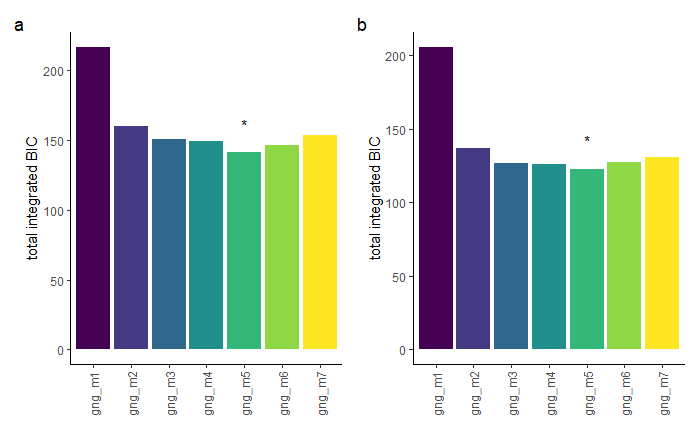

```r
bic_t1_plot + bic_t2_plot + plot_annotation(tag_levels='a')

ggsave(filename = paste0(workingdir,'/figures/bics_plot.png'),width=8,height=5)
```

Get parameters and join to main dataset

```r
model=5

temp<-list()

prefixes<-c('gng_1_',
            'gng_2_')

temp_list<-paste0(prefixes,model)

for (prefix in 1:length(prefixes)){
  name<-load(paste0(temp_list[[prefix]],'.RData'))
  temp[[prefix]]<-get(name)$allIndPars
}

data_modelling<-data%>%
  inner_join(temp[[1]],by=c('id'='subjID'),suffix=c('','_1'))%>%
  inner_join(temp[[2]],by=c('id'='subjID'),suffix=c('','_2'))%>%
  rename('gobias'='b')%>%
  rename('gobias_2'='b_2')
```

Correlate parameters at t1 and t2

```r
data_corr<-
  inner_join(temp[[1]],temp[[2]],by='subjID',suffix=c('_1','_2'))%>%
  pivot_longer(cols=-c('subjID'))%>%
  separate(name,into=c('parameter','time'))

data_corr<-data.frame(cor(temp[[1]]%>%select(-'subjID'),temp[[2]]%>%select(-'subjID')))%>%
  rownames_to_column(var='time1')%>%
  pivot_longer(cols=-c('time1'),names_to = c('time2'))%>%
  mutate(time1=as_factor(time1))%>%
  mutate(time2=as_factor(time2))

ggplot(data=data_corr,aes(x=time1,y=time2))+
  geom_tile(aes(fill=value))+
  geom_text(aes(time1, time2, label = round(value,2)), color = "black")+
  coord_equal()+
  scale_fill_gradient2(low='navy',mid='white',high='firebrick1',midpoint=0,limits=c(-1,1))+
  labs(x= "time1", y = "time2", fill = "Correlation Coefficient")+
  theme(panel.background = element_blank(), axis.ticks = element_blank())+
  scale_x_discrete(position = "top") +
  scale_y_discrete(limits = rev(levels(data_corr$time2)))

ggsave(filename=paste0(workingdir,'figures/gng_m5_cormatrix.png'),width=10,height=10,scale=0.8)
```

[figure not shown]

```r
gng_coefs<-temp[[1]]%>%
  bind_rows(temp[[2]],.id='time')%>%
  mutate(time=as.numeric(time))%>%
  summarise(across(-c(subjID,time), list(corr_coef=function(x) cor.test(x[time==1],x[time==2])$estimate,
                                         corr_p=function(x) cor.test(x[time==1],x[time==2])$p.value,
                                         corr_lb=function(x) cor.test(x[time==1],x[time==2])$conf.int[1],
                                         corr_ub=function(x) cor.test(x[time==1],x[time==2])$conf.int[2],
                                         icc.a1_coef=function(x) icc(cbind(x[time==1],x[time==2]),
                                                                     model = "twoway",
                                                                     type = "agreement",
                                                                     unit = "single",
                                                                     r0=0,
                                                                     conf.level = 0.95)$value,
                                         icc.a1_p=function(x) icc(cbind(x[time==1],x[time==2]),
                                                                  model = "twoway",
                                                                  type = "agreement",
                                                                  unit = "single",
                                                                  r0=0,
                                                                  conf.level = 0.95)$p.value,
                                         icc.a1_lb=function(x) icc(cbind(x[time==1],x[time==2]),
                                                                   model = "twoway",
                                                                   type = "agreement",
                                                                   unit = "single",
                                                                   r0=0,
                                                                   conf.level = 0.95)$lb,
                                         icc.a1_ub=function(x) icc(cbind(x[time==1],x[time==2]),
                                                                   model = "twoway",
                                                                   type = "agreement",
                                                                   unit = "single",
                                                                   r0=0,
                                                                   conf.level = 0.95)$ub,
                                         icc.c1_coef=function(x) icc(cbind(x[time==1],x[time==2]),
                                                                     model = "twoway",
                                                                     type = "consistency",
                                                                     unit = "single",
                                                                     r0=0,
                                                                     conf.level = 0.95)$value,
                                         icc.c1_p=function(x) icc(cbind(x[time==1],x[time==2]),
                                                                  model = "twoway",
                                                                  type = "consistency",
                                                                  unit = "single",
                                                                  r0=0,
                                                                  conf.level = 0.95)$p.value,
                                         icc.c1_lb=function(x) icc(cbind(x[time==1],x[time==2]),
                                                                   model = "twoway",
                                                                   type = "consistency",
                                                                   unit = "single",
                                                                   r0=0,
                                                                   conf.level = 0.95)$lb,
                                         icc.c1_ub=function(x) icc(cbind(x[time==1],x[time==2]),
                                                                   model = "twoway",
                                                                   type = "consistency",
                                                                   unit = "single",
                                                                   r0=0,
                                                                   conf.level = 0.95)$ub)))%>%
  pivot_longer(cols=everything())%>%
  separate(name,into=c('parameter','analysis','number'),sep='_')%>%
  pivot_wider(names_from=number,values_from=value)

gng<-ggplot(gng_coefs,aes(x=parameter,y=coef,colour=analysis,group=analysis))+
  geom_errorbar(aes(ymin=lb,ymax=ub),position=position_dodge(0.5))+
  geom_point(position=position_dodge(0.5))+
  theme_minimal()+
  labs(x='Parameter',y='Estimate and 95% confidence interval',colour='Analysis')+
  scale_x_discrete(labels=c('Approach bias','Avoid bias','Go bias', 'Learning rate','Punishment sensitivity','Reward sensivitiy','Noise'))+
  scale_colour_discrete(labels=c('Pearsons correlation','ICC(A,1)','ICC(C,1)'))

ggsave(filename=paste0(workingdir,'figures/params_stats.png'),width=12,height=6,scale=0.8,gng)
```

*CIRCLES*

EZDDM

```r
ezdm1<-ezddm(propCorrect = data$p_big_medium_1,rtCorrectVariance_seconds = data$rt_big_variance_1, rtCorrectMean_seconds = data$rt_big_mean_1, s=0.1, nTrials = 120)
ezdm2<-ezddm(propCorrect = data$p_big_medium_2,rtCorrectVariance_seconds = data$rt_big_variance_2, rtCorrectMean_seconds = data$rt_big_mean_2, s=0.1, nTrials = 120)
data_modelling<-data_modelling%>%
  bind_cols(ezdm1)%>%
  plyr::rename(c('a'='boundary_1','v'='drift_1','Ter'='nondecisiontime_1'))%>%
  bind_cols(ezdm2)%>%
  plyr::rename(c('a'='boundary_2','v'='drift_2','Ter'='nondecisiontime_2'))
```

Get ICCs for EZ-DDM

```r
#nondecision time
cor_nondec<-cor.test(data_modelling$nondecisiontime_1,data_modelling$nondecisiontime_2)
cor_nondec
```

```
    Pearson's product-moment correlation

data:  data_modelling$nondecisiontime_1 and data_modelling$nondecisiontime_2
t = 5.1256, df = 51, p-value = 4.615e-06
alternative hypothesis: true correlation is not equal to 0
95 percent confidence interval:
 0.3713136 0.7371950
sample estimates:
      cor
0.5830866
```

```r
icc_a1_nondec<-icc(cbind(data_modelling$nondecisiontime_1,data_modelling$nondecisiontime_2),model = "twoway",
    type = "agreement",
    unit = "single",
    r0 = 0,
    conf.level = 0.95)
print(icc_a1_nondec)
```

```
 Single Score Intraclass Correlation

   Model: twoway
   Type : agreement

   Subjects = 53
     Raters = 2
   ICC(A,1) = 0.571

 F-Test, H0: r0 = 0 ; H1: r0 > 0
 F(52,50.7) = 3.79 , p = 2.32e-06

 95%-Confidence Interval for ICC Population Values:
  0.36 < ICC < 0.727
```

```r
icc_c1_nondec<-icc(cbind(data_modelling$nondecisiontime_1,data_modelling$nondecisiontime_2),model = "twoway",
    type = "consistency",
    unit = "single",
    r0 = 0,
    conf.level = 0.95)
print(icc_c1_nondec)
```

```
 Single Score Intraclass Correlation

   Model: twoway
   Type : consistency

   Subjects = 53
     Raters = 2
   ICC(C,1) = 0.583

 F-Test, H0: r0 = 0 ; H1: r0 > 0
   F(52,52) = 3.79 , p = 1.89e-06

 95%-Confidence Interval for ICC Population Values:
  0.373 < ICC < 0.736
```

```r
#drift rate
cor_drift<-cor.test(data_modelling$drift_1,data_modelling$drift_2)
cor_drift
```

```
    Pearson's product-moment correlation

data:  data_modelling$drift_1 and data_modelling$drift_2
t = 2.6244, df = 55, p-value = 0.01121
alternative hypothesis: true correlation is not equal to 0
95 percent confidence interval:
 0.07998805 0.54665201
sample estimates:
      cor
0.3336027
```

```r
icc_a1_drift<-icc(cbind(data_modelling$drift_1,data_modelling$drift_2),model = "twoway",
    type = "agreement",
    unit = "single",
    r0 = 0,
    conf.level = 0.95)
print(icc_a1_drift)
```

```
 Single Score Intraclass Correlation

   Model: twoway
   Type : agreement

   Subjects = 57
     Raters = 2
   ICC(A,1) = 0.33

 F-Test, H0: r0 = 0 ; H1: r0 > 0
   F(56,56) = 1.97 , p = 0.00615

 95%-Confidence Interval for ICC Population Values:
  0.076 < ICC < 0.544
```

```r
icc_c1_drift<-icc(cbind(data_modelling$drift_1,data_modelling$drift_2),model = "twoway",
    type = "consistency",
    unit = "single",
    r0 = 0,
    conf.level = 0.95)
print(icc_c1_drift)
```

```
 Single Score Intraclass Correlation

   Model: twoway
   Type : consistency

   Subjects = 57
     Raters = 2
   ICC(C,1) = 0.327

 F-Test, H0: r0 = 0 ; H1: r0 > 0
   F(56,56) = 1.97 , p = 0.00616

 95%-Confidence Interval for ICC Population Values:
  0.074 < ICC < 0.54
```

```r
#boundary separation
cor_boundary<-cor.test(data_modelling$boundary_1,data_modelling$boundary_2)
cor_boundary
```

```
    Pearson's product-moment correlation

data:  data_modelling$boundary_1 and data_modelling$boundary_2
t = 2.3994, df = 51, p-value = 0.02011
alternative hypothesis: true correlation is not equal to 0
95 percent confidence interval:
 0.0527360 0.5421153
sample estimates:
    cor
0.31849
```

```r
icc_a1_boundary<-icc(cbind(data_modelling$boundary_1,data_modelling$boundary_2),model = "twoway",
    type = "agreement",
    unit = "single",
    r0 = 0,
    conf.level = 0.95)
print(icc_a1_boundary)
```

```
 Single Score Intraclass Correlation

   Model: twoway
   Type : agreement

   Subjects = 53
     Raters = 2
   ICC(A,1) = 0.316

 F-Test, H0: r0 = 0 ; H1: r0 > 0
 F(52,52.9) = 1.93 , p = 0.00923

 95%-Confidence Interval for ICC Population Values:
  0.056 < ICC < 0.537
```

```r
icc_c1_boundary<-icc(cbind(data_modelling$boundary_1,data_modelling$boundary_2),model = "twoway",
    type = "consistency",
    unit = "single",
    r0 = 0,
    conf.level = 0.95)
print(icc_c1_boundary)
```

```
 Single Score Intraclass Correlation

   Model: twoway
   Type : consistency

   Subjects = 53
     Raters = 2
   ICC(C,1) = 0.318

 F-Test, H0: r0 = 0 ; H1: r0 > 0
   F(52,52) = 1.93 , p = 0.00956

 95%-Confidence Interval for ICC Population Values:
  0.055 < ICC < 0.54
```

Create plots

```r
ezddm_coefs<-data.frame(
  measure=c('nondecision','drift','boundary'),
  corr_coef=c(cor_nondec$estimate,cor_drift$estimate,cor_boundary$estimate),
  corr_p=c(cor_nondec$p.value,cor_drift$p.value,cor_boundary$p.value),
  corr_lb=c(cor_nondec$conf.int[1],cor_drift$conf.int[1],cor_boundary$conf.int[1]),
  corr_ub=c(cor_nondec$conf.int[2],cor_drift$conf.int[2],cor_boundary$conf.int[2]),
  icc.a1_coef=c(icc_a1_nondec$value,icc_a1_drift$value,icc_a1_boundary$value),
  icc.a1_p=c(icc_a1_nondec$p.value,icc_a1_drift$p.value,icc_a1_boundary$p.value),
  icc.a1_lb=c(icc_a1_nondec$lbound,icc_a1_drift$lbound,icc_a1_boundary$lbound),
  icc.a1_ub=c(icc_a1_nondec$ubound,icc_a1_drift$ubound,icc_a1_boundary$ubound),
  icc.c1_coef=c(icc_c1_nondec$value,icc_c1_drift$value,icc_c1_boundary$value),
  icc.c1_p=c(icc_c1_nondec$p.value,icc_c1_drift$p.value,icc_c1_boundary$p.value),
  icc.c1_lb=c(icc_c1_nondec$lbound,icc_c1_drift$lbound,icc_c1_boundary$lbound),
  icc.c1_ub=c(icc_c1_nondec$ubound,icc_c1_drift$ubound,icc_c1_boundary$ubound)
)

ezddm_coefs<-ezddm_coefs%>%
  pivot_longer(cols = -c(measure))%>%
  separate(col = name, into=c('analysis','number'), sep = '_')%>%
  pivot_wider(names_from=number,values_from=value)

ezddm_plot<-ggplot(ezddm_coefs,aes(x=measure,y=coef,colour=analysis,group=analysis))+
  geom_errorbar(aes(ymin=lb,ymax=ub),position=position_dodge(0.5))+
  geom_point(position=position_dodge(0.5))+
  theme_minimal()+
  labs(x='Measure',y='Estimate and 95% confidence interval',colour='Analysis')+
  scale_x_discrete(labels=c('Boundary separation','Drift rate','Non-decision time'))+
  scale_colour_discrete(labels=c('Pearsons correlation','ICC(A,1)','ICC(C,1)'))

ggsave(filename=paste0(workingdir,'figures/ezddm_stats.png'),width=10,height=6,scale=0.8,ezddm_plot)
```

Check against full DDM

Get parameters and join to main dataset

```r
temp<-list()

prefixes<-c('ddm_1',
            'ddm_2')

temp_list<-paste0(prefixes)

for (prefix in 1:length(prefixes)){
  name<-load(paste0(temp_list[[prefix]],'.RData'))
  temp[[prefix]]<-get(name)$allIndPars
}

data_modelling<-data_modelling%>%
  mutate(id=as.numeric(substr(id,2,3)))%>% #to get model to run, had to remove 'P', so doing this so they match
  inner_join(temp[[1]],by=c('id'='subjID'),suffix=c('','_1'))%>%
  inner_join(temp[[2]],by=c('id'='subjID'),suffix=c('','_2'))%>%
  mutate(id=paste0('P',id)) #adding 'P' back on to ids
```

Correlate parameters at t1 and t2

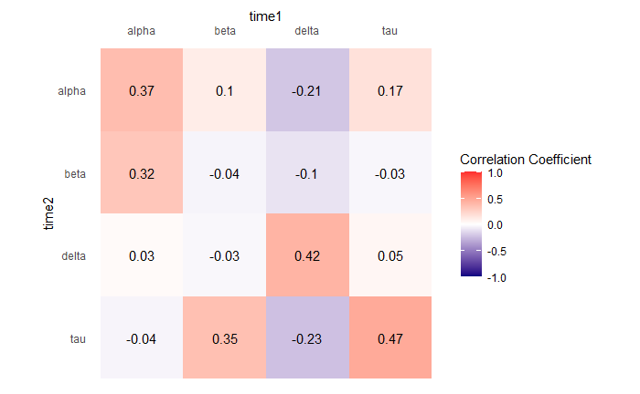

```r
data_corr<-data.frame(cor(temp[[1]]%>%filter(subjID %in% temp[[2]]$subjID)%>%select(-'subjID'),temp[[2]]%>%select(-'subjID')))%>%
  rownames_to_column(var='time1')%>%
  pivot_longer(cols=-c('time1'),names_to = c('time2'))%>%
  mutate(time1=as_factor(time1))%>%
  mutate(time2=as_factor(time2))

ggplot(data=data_corr,aes(x=time1,y=time2))+
  geom_tile(aes(fill=value))+
  geom_text(aes(time1, time2, label = round(value,2)), color = "black")+
  coord_equal()+
  scale_fill_gradient2(low='navy',mid='white',high='firebrick1',midpoint=0,limits=c(-1,1))+
  labs(x= "time1", y = "time2", fill = "Correlation Coefficient")+
  theme(panel.background = element_blank(), axis.ticks = element_blank())+
  scale_x_discrete(position = "top") +
  scale_y_discrete(limits = rev(levels(data_corr$time2)))
```

Plot full DDM correlations

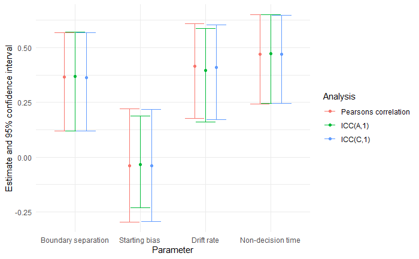

```r
temp[[1]]<-filter(temp[[1]],subjID %in% temp[[2]]$subjID)

ddm_coefs<-temp[[1]]%>%
  bind_rows(temp[[2]],.id='time')%>%
  mutate(time=as.numeric(time))%>%
  summarise(across(-c(subjID,time), list(corr_coef=function(x) cor.test(x[time==1],x[time==2])$estimate,
                                         corr_p=function(x) cor.test(x[time==1],x[time==2])$p.value,
                                         corr_lb=function(x) cor.test(x[time==1],x[time==2])$conf.int[1],
                                         corr_ub=function(x) cor.test(x[time==1],x[time==2])$conf.int[2],
                                         icc.a1_coef=function(x) icc(cbind(x[time==1],x[time==2]),
                                                                     model = "twoway",
                                                                     type = "agreement",
                                                                     unit = "single",
                                                                     r0=0,
                                                                     conf.level = 0.95)$value,
                                         icc.a1_p=function(x) icc(cbind(x[time==1],x[time==2]),
                                                                  model = "twoway",
                                                                  type = "agreement",
                                                                  unit = "single",
                                                                  r0=0,
                                                                  conf.level = 0.95)$p.value,
                                         icc.a1_lb=function(x) icc(cbind(x[time==1],x[time==2]),
                                                                   model = "twoway",
                                                                   type = "agreement",
                                                                   unit = "single",
                                                                   r0=0,
                                                                   conf.level = 0.95)$lb,
                                         icc.a1_ub=function(x) icc(cbind(x[time==1],x[time==2]),
                                                                   model = "twoway",
                                                                   type = "agreement",
                                                                   unit = "single",
                                                                   r0=0,
                                                                   conf.level = 0.95)$ub,
                                         icc.c1_coef=function(x) icc(cbind(x[time==1],x[time==2]),
                                                                     model = "twoway",
                                                                     type = "consistency",
                                                                     unit = "single",
                                                                     r0=0,
                                                                     conf.level = 0.95)$value,
                                         icc.c1_p=function(x) icc(cbind(x[time==1],x[time==2]),
                                                                  model = "twoway",
                                                                  type = "consistency",
                                                                  unit = "single",
                                                                  r0=0,
                                                                  conf.level = 0.95)$p.value,
                                         icc.c1_lb=function(x) icc(cbind(x[time==1],x[time==2]),
                                                                   model = "twoway",
                                                                   type = "consistency",
                                                                   unit = "single",
                                                                   r0=0,
                                                                   conf.level = 0.95)$lb,
                                         icc.c1_ub=function(x) icc(cbind(x[time==1],x[time==2]),
                                                                   model = "twoway",
                                                                   type = "consistency",
                                                                   unit = "single",
                                                                   r0=0,
                                                                   conf.level = 0.95)$ub)))%>%
  pivot_longer(cols=everything())%>%
  separate(name,into=c('parameter','analysis','number'),sep='_')%>%
  pivot_wider(names_from=number,values_from=value)

ddm<-ggplot(ddm_coefs,aes(x=parameter,y=coef,colour=analysis,group=analysis))+
  geom_errorbar(aes(ymin=lb,ymax=ub),position=position_dodge(0.5))+
  geom_point(position=position_dodge(0.5))+
  theme_minimal()+
  labs(x='Parameter',y='Estimate and 95% confidence interval',colour='Analysis')+
  scale_x_discrete(labels=c('Boundary separation','Starting bias','Drift rate','Non-decision time'))+
  scale_colour_discrete(labels=c('Pearsons correlation','ICC(A,1)','ICC(C,1)'))

ddm
ggsave(filename=paste0(workingdir,'figures/ddm_stats.png'),width=12,height=6,scale=0.8,ddm)
```

Combine figures for models

[figure not shown]

```r
(gng / ezddm_plot / ddm) * theme(axis.text.x = element_text(angle=45, hjust=1)) * geom_hline(yintercept = 0,linetype='dotted') * geom_hline(yintercept = 0.4, linetype='dotdash') * ylim(-0.45,0.75) + plot_annotation(tag_level = 'a') + plot_layout(guides='collect')
ggsave(paste0(filename='figures/model_cors.png'),height=15,width=11,scale=0.8)
```

Check correlations between EZDDM and DDM parameters

```r
cor.test(data_modelling$tau,data_modelling$nondecisiontime_1)
```

```
    Pearson's product-moment correlation

data:  data_modelling$tau and data_modelling$nondecisiontime_1
t = 9.8646, df = 52, p-value = 1.661e-13
alternative hypothesis: true correlation is not equal to 0
95 percent confidence interval:
 0.6883301 0.8839768
sample estimates:
      cor
0.8072992
```

```r
cor.test(data_modelling$tau_2,data_modelling$nondecisiontime_2)
```

```
    Pearson's product-moment correlation

data:  data_modelling$tau_2 and data_modelling$nondecisiontime_2
t = 9.373, df = 55, p-value = 5.386e-13
alternative hypothesis: true correlation is not equal to 0
95 percent confidence interval:
 0.6581247 0.8675114
sample estimates:
      cor
0.7842111
```

```r
cor.test(data_modelling$alpha,data_modelling$boundary_1)
```

```
    Pearson's product-moment correlation

data:  data_modelling$alpha and data_modelling$boundary_1
t = 6.7157, df = 52, p-value = 1.405e-08
alternative hypothesis: true correlation is not equal to 0
95 percent confidence interval:
 0.5061250 0.8027884
sample estimates:
      cor
0.6815251
```

```r
cor.test(data_modelling$alpha_2,data_modelling$boundary_2)
```

```
    Pearson's product-moment correlation

data:  data_modelling$alpha_2 and data_modelling$boundary_2
t = 4.7316, df = 55, p-value = 1.598e-05
alternative hypothesis: true correlation is not equal to 0
95 percent confidence interval:
 0.3224870 0.7002826
sample estimates:
      cor
0.5378586
```

```r
cor.test(data_modelling$beta,data_modelling$drift_1)
```

```
    Pearson's product-moment correlation

data:  data_modelling$beta and data_modelling$drift_1
t = 0.96645, df = 55, p-value = 0.3381
alternative hypothesis: true correlation is not equal to 0
95 percent confidence interval:
 -0.1359214  0.3770933
sample estimates:
      cor
0.1292229
```

```r
cor.test(data_modelling$beta_2,data_modelling$drift_2)
```

```
    Pearson's product-moment correlation

data:  data_modelling$beta_2 and data_modelling$drift_2
t = 1.9244, df = 56, p-value = 0.05939
alternative hypothesis: true correlation is not equal to 0
95 percent confidence interval:
 -0.009879189  0.476683271
sample estimates:
      cor
0.2490521
```

```r
cor.test(data_modelling$delta,data_modelling$drift_1)
```

```
    Pearson's product-moment correlation

data:  data_modelling$delta and data_modelling$drift_1
t = -13.477, df = 55, p-value < 2.2e-16
alternative hypothesis: true correlation is not equal to 0
95 percent confidence interval:
 -0.925417 -0.797628
sample estimates:
       cor
-0.8761087
```

```r
cor.test(data_modelling$delta_2,data_modelling$drift_2)
```

```
    Pearson's product-moment correlation

data:  data_modelling$delta_2 and data_modelling$drift_2
t = -18.755, df = 56, p-value < 2.2e-16
alternative hypothesis: true correlation is not equal to 0
95 percent confidence interval:
 -0.9574059 -0.8821251
sample estimates:
       cor
-0.9287956
```

Gng posterior prediction

Get trialwise likelihoods for session 1 and session 2 and using parameters from other session to predict

```r
source(paste0(workingdir,'get_mean_trialwise_likelihood.R'))
source(paste0(workingdir,'gng_m5_forward.R'))

params<-c('ep','app','av','xi','gobias','rhoRew','rhoPun')

#session 1 predicting session 1

s1s1<-get_mean_trialwise_likelihood('gng',data_modelling,params,1,1)
#session 2 predicting session 2

s2s2<-get_mean_trialwise_likelihood('gng',data_modelling,params,2,2)
#session 1 predicting session 2
s1s2<-get_mean_trialwise_likelihood('gng',data_modelling,params,1,2)
#session 2 predicting session 1
s2s1<-get_mean_trialwise_likelihood('gng',data_modelling,params,2,1)
#session 1 mean params predicting session 2
s1means2<-get_mean_trialwise_likelihood('gng',data_modelling,params,1,2,mean_parameters = 1)
#session 2 mean params predicting session 1
s2means1<-get_mean_trialwise_likelihood('gng',data_modelling,params,2,1,mean_parameters = 1)
```

Plot

```r
trialwise_likelihoods<-data.frame(s1s1,s2s2,s1s2,s2s1,s1means2,s2means1)

t.test(trialwise_likelihoods$s1s2,trialwise_likelihoods$s1means2,paired=TRUE)
```

```
    Paired t-test

data:  trialwise_likelihoods$s1s2 and trialwise_likelihoods$s1means2
t = 0.27779, df = 57, p-value = 0.7822
alternative hypothesis: true difference in means is not equal to 0
95 percent confidence interval:
 -0.03713249  0.04909434
sample estimates:
mean of the differences
            0.005980928
```

```r
t.test(trialwise_likelihoods$s2s1,trialwise_likelihoods$s2means1,paired=TRUE)
```

```
    Paired t-test

data:  trialwise_likelihoods$s2s1 and trialwise_likelihoods$s2means1
t = 2.4536, df = 57, p-value = 0.01722
alternative hypothesis: true difference in means is not equal to 0
95 percent confidence interval:
 0.009674361 0.095549072
sample estimates:
mean of the differences
             0.05261172
```

```r
t.test(trialwise_likelihoods$s1s2,mu=0.5)
```

```
    One Sample t-test

data:  trialwise_likelihoods$s1s2
t = 5.742, df = 57, p-value = 3.791e-07
alternative hypothesis: true mean is not equal to 0.5
95 percent confidence interval:
 0.5866793 0.6795104
sample estimates:
mean of x
0.6330948
```

```r
t.test(trialwise_likelihoods$s2s1,mu=0.5)
```

```
    One Sample t-test

data:  trialwise_likelihoods$s2s1
t = 5.7021, df = 57, p-value = 4.401e-07
alternative hypothesis: true mean is not equal to 0.5
95 percent confidence interval:
 0.5854042 0.6778572
sample estimates:
mean of x
0.6316307
```

```r
data_difference<-trialwise_likelihoods%>%
  mutate(difference_session1params=s1s2-s1means2)%>%
  mutate(difference_session2params=s2s1-s2means1)%>%
  rownames_to_column(var='id')%>%
  select(id,difference_session1params,difference_session2params)%>%
  pivot_longer(cols=-c(id),names_to='metric',values_to = 'difference in trialwise likelihood')

likelihood_diff_gng<-ggplot(data=data_difference,aes(x=metric,y=`difference in trialwise likelihood`,fill=metric))+
  geom_boxplot()+
  theme_classic()+
  geom_hline(aes(yintercept=0),linetype='dashed')+
  labs(y='difference in trialwise likelihood between \n indvidual parameters and mean parameters',title='Go-Nogo task')

trialwise_likelihoods_plotting<-trialwise_likelihoods%>%
  rownames_to_column(var='id')%>%
  pivot_longer(cols=-c(id),names_to='metric',values_to='trialwise likelihood')

prediction_gng<-ggplot(trialwise_likelihoods_plotting%>%filter(metric!='s1means2'&metric!='s2means1'),aes(x=metric,y=`trialwise likelihood`,fill=metric))+
  geom_boxplot()+
  theme_classic()+
  geom_hline(aes(yintercept=0.5),linetype='dashed')+
  labs(y='trialwise likelihood',title='Go-Nogo task')
```

Circles ddm

Get trialwise likelihoods for session 1 and session 2 and using parameters from other session to predict

```r
source(paste0(workingdir,'get_mean_trialwise_likelihood.R'))
source(paste0(workingdir,'ddm_forward.R'))

params<-c('alpha','beta','tau','delta')

#session 1 predicting session 1

s1s1<-get_mean_trialwise_likelihood('ddm',data_modelling,params,1,1)
#session 2 predicting session 2

s2s2<-get_mean_trialwise_likelihood('ddm',data_modelling,params,2,2)
#session 1 predicting session 2
s1s2<-get_mean_trialwise_likelihood('ddm',data_modelling,params,1,2)
#session 2 predicting session 1
s2s1<-get_mean_trialwise_likelihood('ddm',data_modelling,params,2,1)
#session 1 mean params predicting session 2
s1means2<-get_mean_trialwise_likelihood('ddm',data_modelling,params,1,2,mean_parameters = 1)
#session 2 mean params predicting session 1
s2means1<-get_mean_trialwise_likelihood('ddm',data_modelling,params,2,1,mean_parameters = 1)
```

Plot

```r
trialwise_likelihoods<-data.frame(s1s1,s2s2,s1s2,s2s1,s1means2,s2means1)

t.test(trialwise_likelihoods$s1s2,trialwise_likelihoods$s1means2,paired=TRUE)
```

```
    Paired t-test

data:  trialwise_likelihoods$s1s2 and trialwise_likelihoods$s1means2
t = 1.8046, df = 57, p-value = 0.07643
alternative hypothesis: true difference in means is not equal to 0
95 percent confidence interval:
 -0.002178802  0.041911105
sample estimates:
mean of the differences
             0.01986615
```

```r
t.test(trialwise_likelihoods$s2s1,trialwise_likelihoods$s2means1,paired=TRUE)
```

```
    Paired t-test

data:  trialwise_likelihoods$s2s1 and trialwise_likelihoods$s2means1
t = 1.403, df = 57, p-value = 0.1661
alternative hypothesis: true difference in means is not equal to 0
95 percent confidence interval:
 -0.00785883  0.04464124
sample estimates:
mean of the differences
             0.01839121
```

```r
t.test(trialwise_likelihoods$s1s2,mu=0.5)
```

```
    One Sample t-test

data:  trialwise_likelihoods$s1s2
t = 6.3023, df = 57, p-value = 4.579e-08
alternative hypothesis: true mean is not equal to 0.5
95 percent confidence interval:
 0.5588686 0.6137002
sample estimates:
mean of x
0.5862844
```

```r
t.test(trialwise_likelihoods$s2s1,mu=0.5)
```

```
    One Sample t-test

data:  trialwise_likelihoods$s2s1
t = 6.3548, df = 57, p-value = 3.749e-08
alternative hypothesis: true mean is not equal to 0.5
95 percent confidence interval:
 0.5598662 0.6149533
sample estimates:
mean of x
0.5874097
```

```r
data_difference<-trialwise_likelihoods%>%
  mutate(difference_session1params=s1s2-s1means2)%>%
  mutate(difference_session2params=s2s1-s2means1)%>%
  rownames_to_column(var='id')%>%
  select(id,difference_session1params,difference_session2params)%>%
  pivot_longer(cols=-c(id),names_to='metric',values_to = 'difference in trialwise likelihood')

likelihood_diff_ddm<-ggplot(data=data_difference,aes(x=metric,y=`difference in trialwise likelihood`,fill=metric))+
  geom_boxplot()+
  theme_classic()+
  geom_hline(aes(yintercept=0),linetype='dashed')+
  labs(y='difference in trialwise likelihood between \n indvidual parameters and mean parameters',title='Ambiguous midpoint task')

trialwise_likelihoods_plotting<-trialwise_likelihoods%>%
  rownames_to_column(var='id')%>%
  pivot_longer(cols=-c(id),names_to='metric',values_to='trialwise likelihood')

prediction_ddm<-ggplot(trialwise_likelihoods_plotting%>%filter(metric!='s1means2'&metric!='s2means1'),aes(x=metric,y=`trialwise likelihood`,fill=metric))+
  geom_boxplot()+
  theme_classic()+
  geom_hline(aes(yintercept=0.5),linetype='dashed')+
  labs(y='trialwise likelihood',title='Ambiguous midpoint task')
```

Plot

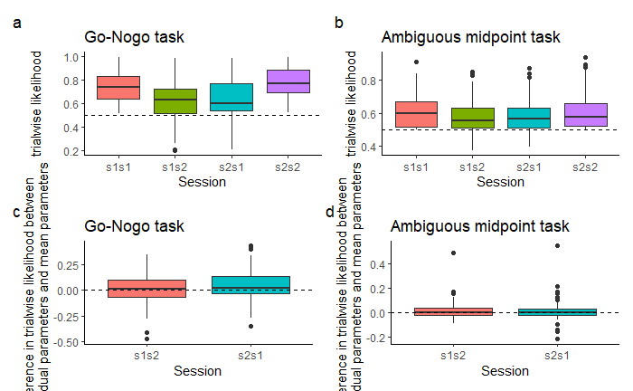

```r
(prediction_gng + prediction_ddm)* theme(legend.position='none') * labs(x='Session')/ ((likelihood_diff_gng + likelihood_diff_ddm) * scale_x_discrete(labels=c('s1s2','s2s1')) * labs(x='Session') * theme(legend.position='none')) + plot_annotation(tag_level = 'a')
ggsave(paste0(filename='figures/posterior_prediction.png'),height=8,width=11,scale=0.8)
```

Look at models with correlations embedded

Gng

```r
fit<-readRDS(paste0(workingdir,'gng_m5_testretest.RDS'))

parameters<-c('xi','ep','b','app','av','rhoRew','rhoPun')
parameters_pr<-paste0(parameters,'_pr')

into=c('parameter','id','time')
#into=c('parameter',NA,'time','id')

pars_testretest<-colMeans(colMeans(fit$draws(parameters)))%>%
  data.frame()%>%
  rownames_to_column(var='parameter')%>%
  separate(col=parameter,into=into)%>%
  rename(value='.')%>%
  pivot_wider(names_from=c(time),values_from='value')
correlations<-pars_testretest%>%
  group_by(parameter)%>%
  summarise(correlation=cor.test(`1`,`2`)$estimate,
            lb=cor.test(`1`,`2`)$conf.int[1],
            ub=cor.test(`1`,`2`)$conf.int[2],)

correlations
```

| parameter | correlation | lb | ub |
| --- | --- | --- | --- |
| app | -0.05576590 | -0.309602140 | 0.2054898 |
| av | 0.81384256 | 0.703412624 | 0.8859095 |
| b | 0.48621247 | 0.260650975 | 0.6614402 |
| ep | 0.25443976 | -0.004127258 | 0.4811162 |
| rhoPun | -0.05964116 | -0.313113406 | 0.2017628 |
| rhoRew | 0.81403116 | 0.703694823 | 0.8860296 |
| xi | 0.06444605 | -0.197131202 | 0.3174574 |

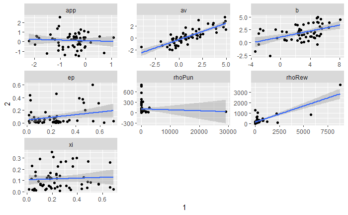

```r
ggplot(pars_testretest,aes(x=`1`,y=`2`))+
  geom_point()+
  geom_smooth(method='lm')+
  facet_wrap(facets='parameter',scales='free')
into=c(NA,'parameter','time','id')
corr_gng<-fit$summary(paste0('R_',parameters),'mean', ~quantile(.x, probs = c(0.05, 0.95)))%>%
  data.frame()%>%
  separate(col=variable,into=into)%>%
  filter(time!=id&time==1)%>%
  rename('correlation'='mean','lb'='X5.','ub'='X95.')
corr_gng<-bind_rows(full=corr_gng,part=correlations,.id='analysis')%>%
    bind_rows(gng_coefs%>%rename('correlation'='coef'))

embed_gng<-ggplot(corr_gng[corr_gng$analysis=='full'|corr_gng$analysis=='corr',],aes(x=parameter,y=correlation,group=analysis,colour=analysis))+
  geom_errorbar(aes(ymin=lb,ymax=ub),position=position_dodge(0.5))+
  geom_point(position=position_dodge(0.5))+
  theme_minimal()+
  labs(x='Measure',y='Estimate and 95% confidence interval',colour='Analysis')+
  scale_x_discrete(labels=c('Approach bias','Avoid bias','Go bias', 'Learning rate','Punishment sensitivity','Reward sensivitiy','Noise'))+
  geom_hline(yintercept=0,linetype='dotted')+
  geom_hline(yintercept=0.4,linetype='dotdash')

ggsave(filename=paste0(workingdir,'figures/gng_embeddedcors.png'),width=10,height=6,scale=0.8,embed_gng)
```

Circles

```r
fit<-readRDS(paste0(workingdir,'choiceRT_ddm_testretest.RDS'))

parameters<-c('alpha','beta','delta','tau')
parameters_pr<-paste0(parameters,'_pr')

into=c('parameter','id','time')
#into=c('parameter',NA,'time','id')

pars_testretest<-colMeans(colMeans(fit$draws(parameters)))%>%
  data.frame()%>%
  rownames_to_column(var='parameter')%>%
  separate(col=parameter,into=into)%>%
  rename(value='.')%>%
  pivot_wider(names_from=c(time),values_from='value')
correlations<-pars_testretest%>%
  group_by(parameter)%>%
  summarise(correlation=cor.test(`1`,`2`)$estimate,
            lb=cor.test(`1`,`2`)$conf.int[1],
            ub=cor.test(`1`,`2`)$conf.int[2],)

correlations
```

| parameter | correlation | lb | ub |
| --- | --- | --- | --- |
| alpha | 0.47207351 | 0.2499685 | 0.6469823 |
| beta | -0.01071474 | -0.2618290 | 0.2417583 |
| delta | 0.48513679 | 0.2657865 | 0.6567269 |
| tau | 0.51413800 | 0.3013307 | 0.6781573 |

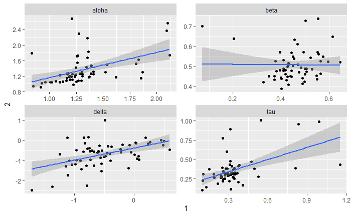

```r
ggplot(pars_testretest,aes(x=`1`,y=`2`))+
  geom_point()+
  geom_smooth(method='lm')+
  facet_wrap(facets='parameter',scales='free')
```

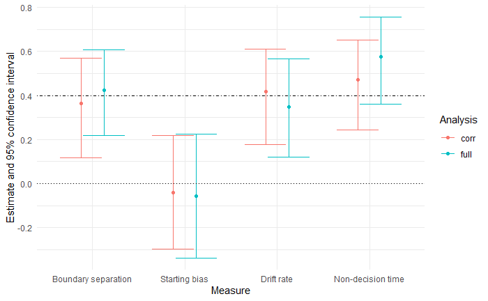

```r
into=c(NA,'parameter','time','id')
corr_circles<-fit$summary(paste0('R_',parameters),'mean', ~quantile(.x, probs = c(0.05, 0.95)))%>%
  data.frame()%>%
  separate(col=variable,into=into)%>%
  filter(time!=id&time==1)%>%
  rename('correlation'='mean','lb'='X5.','ub'='X95.')
corr_circles<-bind_rows(full=corr_circles,part=correlations,.id='analysis')%>%
  bind_rows(ddm_coefs%>%rename('correlation'='coef'))

embed_circles<-ggplot(corr_circles[corr_circles$analysis=='full'|corr_circles$analysis=='corr',],aes(x=parameter,y=correlation,colour=analysis,group=analysis))+
  geom_errorbar(aes(ymin=lb,ymax=ub),position=position_dodge(0.5))+
  geom_point(position=position_dodge(0.5))+
  theme_minimal()+
  labs(x='Measure',y='Estimate and 95% confidence interval',colour='Analysis')+
  scale_x_discrete(labels=c('Boundary separation','Starting bias','Drift rate','Non-decision time'))+
  geom_hline(yintercept=0,linetype='dotted')+
  geom_hline(yintercept=0.4,linetype='dotdash')
embed_circles

ggsave(filename=paste0(workingdir,'figures/circles_embeddedcors.png'),width=10,height=6,scale=0.8)
```

Combine plots

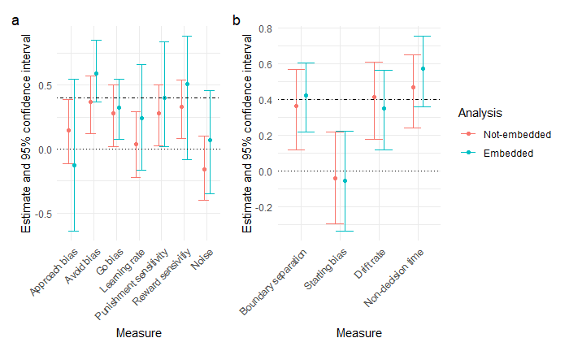

```r
(embed_gng + embed_circles)* theme(axis.text.x = element_text(angle=45, hjust=1)) * geom_hline(yintercept = 0,linetype='dotted') * scale_colour_discrete(labels=c('Not-embedded','Embedded')) + plot_annotation(tag_level = 'a') + plot_layout(guides='collect')
ggsave(paste0(filename='figures/embedded_cors.png'),height=8,width=11,scale=0.8)
```

How big would an effect have to be?

```r
n=10 #start at this number
correlation=0.9
effectsize=0.27

pval=1 #initialises

while (pval>0.05){
  data<-rnorm_multi(n = n,
                    mu = c(0, 0),
                    sd = c(1, 1),
                    r = c(correlation),
                    varnames = c("A", "B"),
                    empirical = TRUE)

  cor.test(data$A,data$B)

  data<-data%>%
    mutate(B_shift=B+effectsize)

  cohen.d(data$A,data$B_shift)
  cor.test(data$A,data$B_shift)

  pval=t.test(data$A,data$B_shift,paired=TRUE)$p.value

  n=n+1
}

n
```

```
[1] 15
```